# Medical Insurance Payout

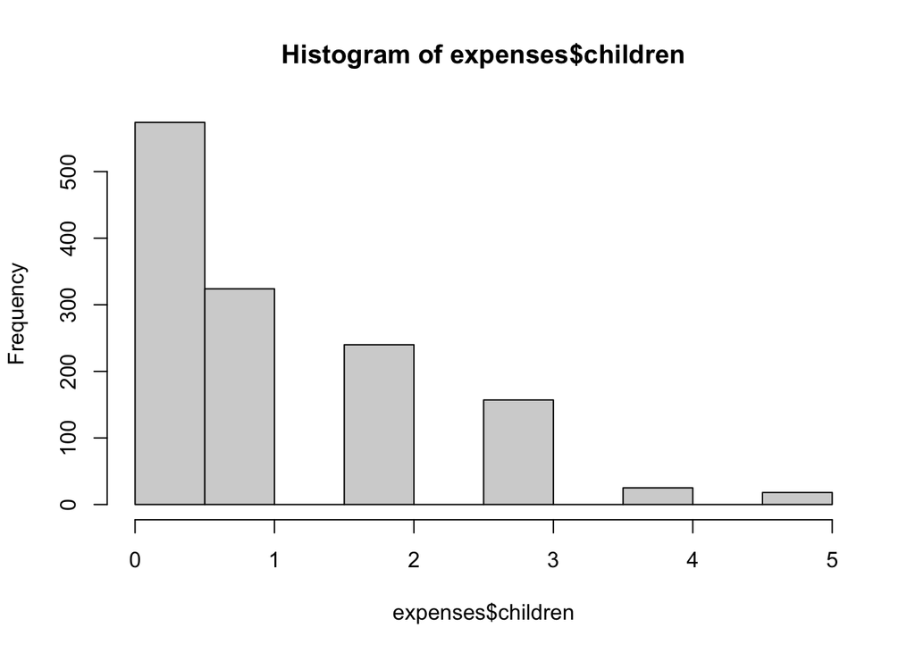

```r
hist(expenses$children)
```

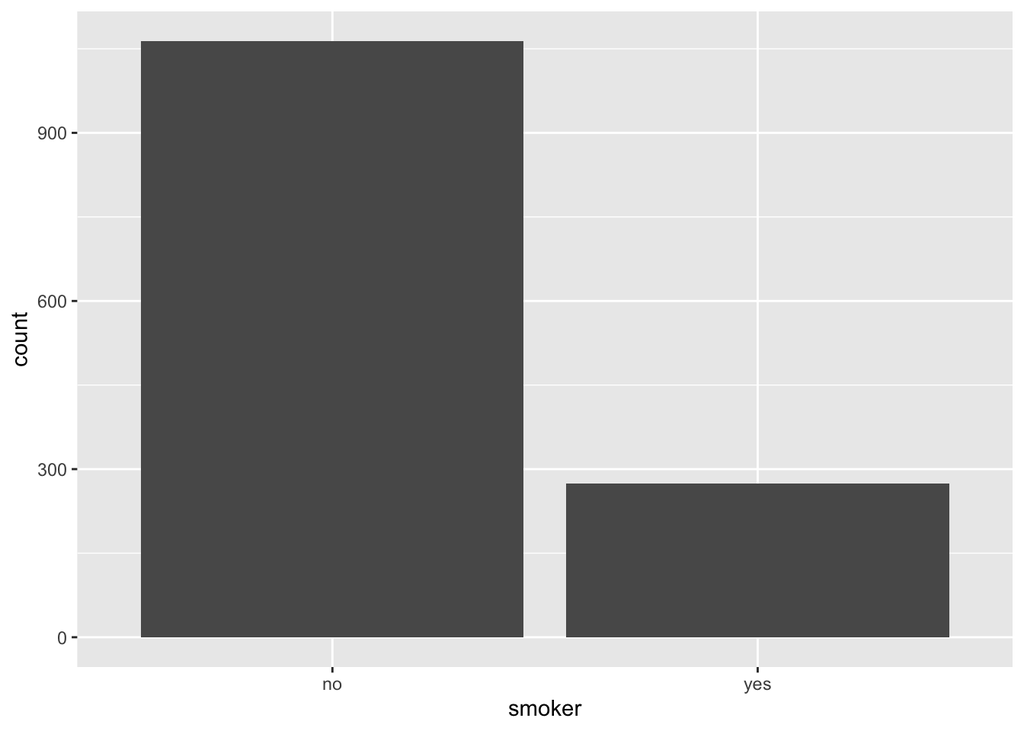

```r
ggplot(expenses, aes(x = smoker)) + geom_bar()
```

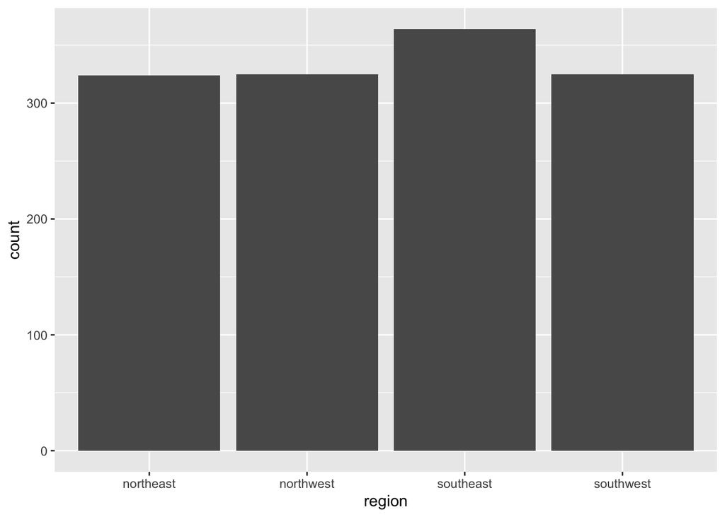

```r
ggplot(expenses, aes(x = region)) + geom_bar()
```

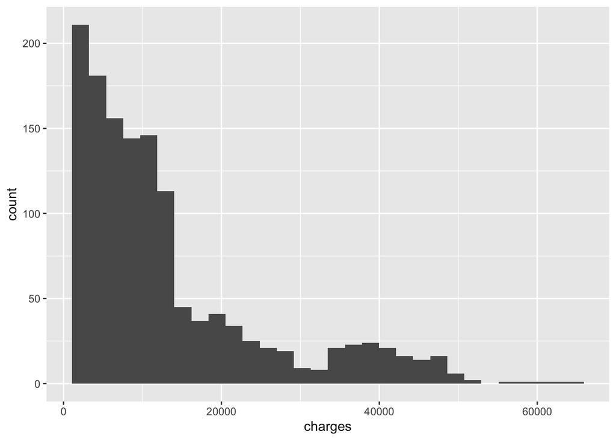

```r
ggplot(expenses, aes(x = charges)) + geom_histogram()
```

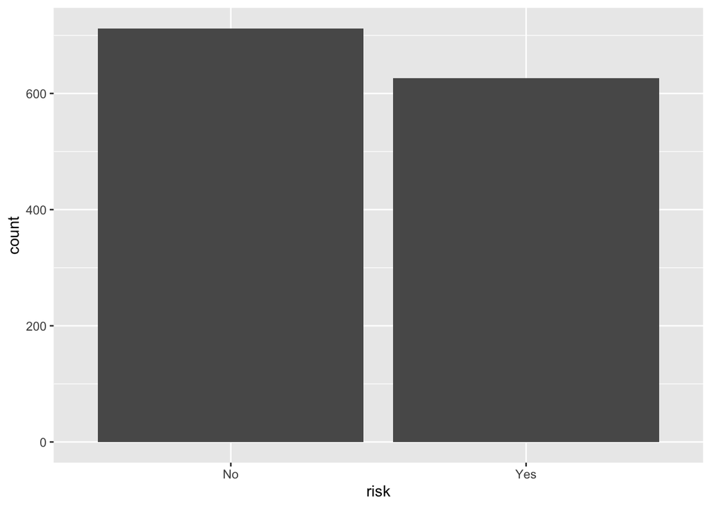

```r
ggplot(expenses, aes(x = risk)) + geom_bar()
```

Let’s create a plot to understand relation between all the numeric variables.

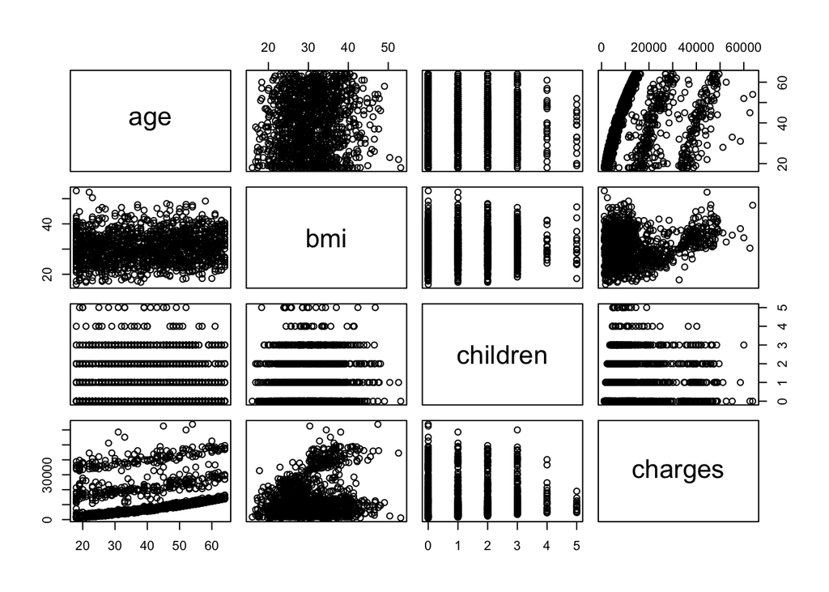

```r
num_col <- unlist(lapply(expenses, is.numeric))
plot(expenses[,num_col])
```

In this plot we can see some of the specific trends that can be useful later in the projects. 1. Interestingly, when the number of children is greater than 3 then charges is significantly low. 2. We can see three bands formation on the charges/age plot

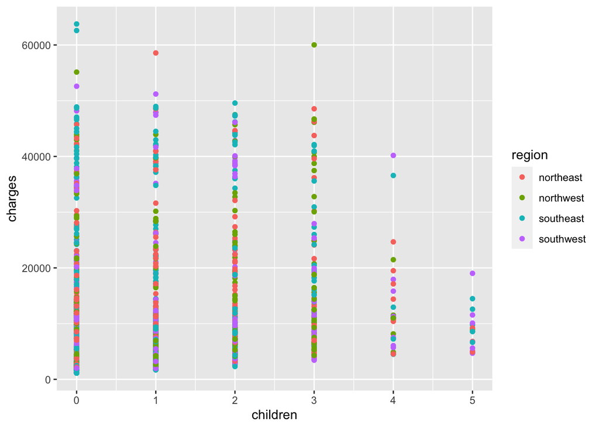

```r
ggplot(expenses, aes(x = children, y = charges)) +
  geom_point(aes(col = region))
```

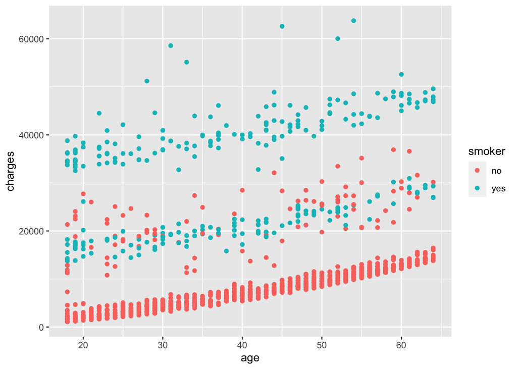

```r
ggplot(expenses, aes(x = age, y = charges)) +
  geom_point(aes(col = smoker))
```

In the first graph of children/charges there is no significant behavior. However, we can clearly see the three bands formation can be distinguished by smokers and non-smokers, smokers having higher charges and non-smokes having lower charges.

Correlation between continuous variables

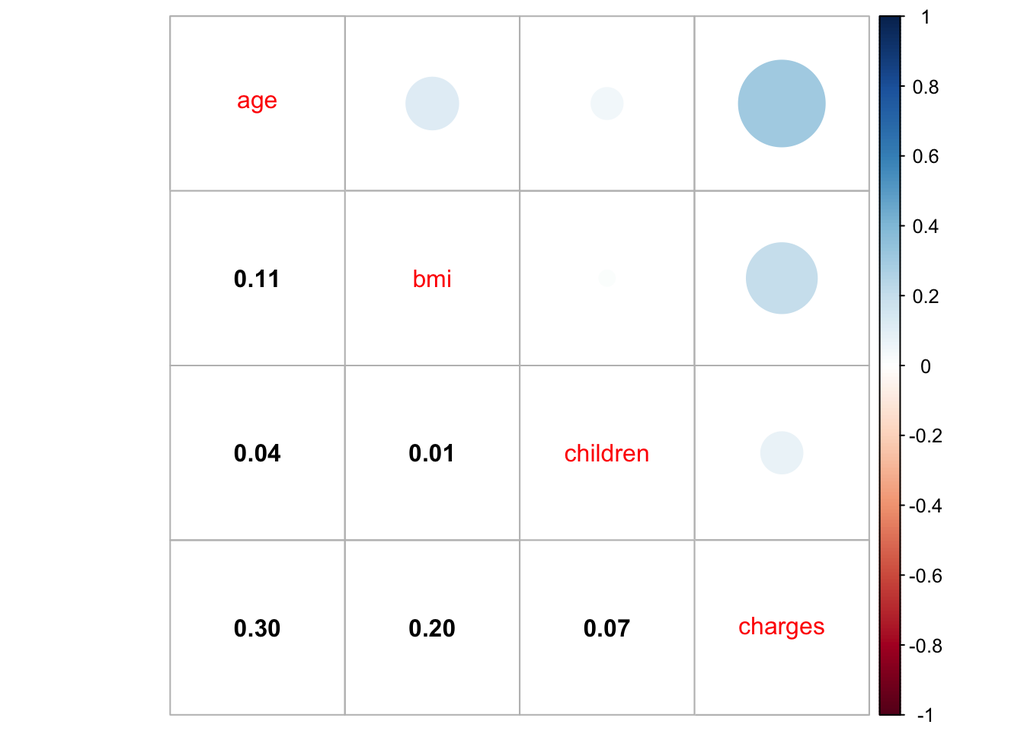

```r
corrplot.mixed(round(cor(expenses[,num_col]), 2), lower.col = "black")
```

Correlation between the charges and the other variables is not even greater than 50%, but still age is the factor with highest correlation of 0.30.

Distribution of Categorical Variables

```r
str(expenses)
```

```
## 'data.frame':    1338 obs. of  8 variables:
##  $ age     : int  19 18 28 33 32 31 46 37 37 60 ...
##  $ sex     : chr  "female" "male" "male" "male" ...
##  $ bmi     : num  27.9 33.8 33 22.7 28.9 ...
##  $ children: int  0 1 3 0 0 0 1 3 2 0 ...
##  $ smoker  : chr  "yes" "no" "no" "no" ...
##  $ region  : chr  "southwest" "southeast" "southeast" "northwest" ...
##  $ charges : num  16885 1726 4449 21984 3867 ...
##  $ risk    : chr  "Yes" "No" "No" "Yes" ...
```

```r
expenses$sex <- as.factor(expenses$sex)
expenses$smoker <- as.factor(expenses$smoker)
expenses$region <- as.factor(expenses$region)
str(expenses)
```

```
## 'data.frame':    1338 obs. of  8 variables:
##  $ age     : int  19 18 28 33 32 31 46 37 37 60 ...
##  $ sex     : Factor w/ 2 levels "female","male": 1 2 2 2 2 1 1 1 2 1 ...
##  $ bmi     : num  27.9 33.8 33 22.7 28.9 ...
##  $ children: int  0 1 3 0 0 0 1 3 2 0 ...
##  $ smoker  : Factor w/ 2 levels "no","yes": 2 1 1 1 1 1 1 1 1 1 ...
##  $ region  : Factor w/ 4 levels "northeast","northwest",..: 4 3 3 2 2 3 3 2 1 2 ...
##  $ charges : num  16885 1726 4449 21984 3867 ...
##  $ risk    : chr  "Yes" "No" "No" "Yes" ...
```

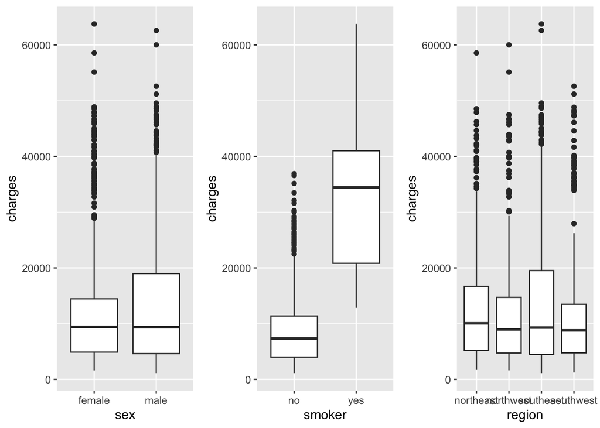

```r
sex_boxplot <- ggplot(expenses, aes(x = sex, y = charges)) +
  geom_boxplot()
smoker_boxplot <- ggplot(expenses, aes(x = smoker, y = charges)) +
  geom_boxplot()
region_boxplot <- ggplot(expenses, aes(x = region, y = charges)) +
  geom_boxplot()
grid.arrange(sex_boxplot, smoker_boxplot, region_boxplot, ncol = 3)
```

Preparing dataset for Modelling